# Yelp Business Dataset EDA

Mishkin Khunger, Sanat Lal, Sharmin Kantharia, Vishal Pathak

21st October 2019

## **Chapter 1: Introduction**

Yelp is a business directory service and crowdsourced review forum. This dataset includes data related many domains – business, checkin, review, tip, user. We have made use of the business data for initial EDA. The data consists of 1,92,000 rows.

### **Smart Questions**

1. Is Star Rating a significant contributor in deciding whether a business will stay active or will discontinue?
2. Yelp owns numerous types of business. We aim to determine the most popular Yelp business for which the user makes use of the yelp application to provide useful ratings and reviews.
3. Is there a significant relationship between the number of reviews received and the ratings obtained, do the ratings increase with the increase in the number of review counts?
4. Is Yelp uniformly distributed among the whole North America or is it just prominent in some selected states?

## **Chapter 2: Data Cleaning**

To clean this data, we found the NA values in each column and deleted those rows, thereby getting a new dataframe. In this new dataframe, the categories column consists of many sub-categories. We split the categories and see that since there are 1000 comma -seperated values which maybe similar to each other but differ by name hence, we cannot implement one hot encoding. Then we grouped these 1000 comma-separated values in to 10 major categories.

The business data consist of many columns, out of which we are working on the following:

1. Name
2. City
3. State
4. Latitude
5. Longitude
6. Stars
7. review_count
8. is_open
9. Categories

## **Chapter 3: Graphical Representation**

In order to work with certain columns such as is_open and categories, we convert them into factors. This allows us to perfrom visualization on them efficiently.

#### *Graph 1:*

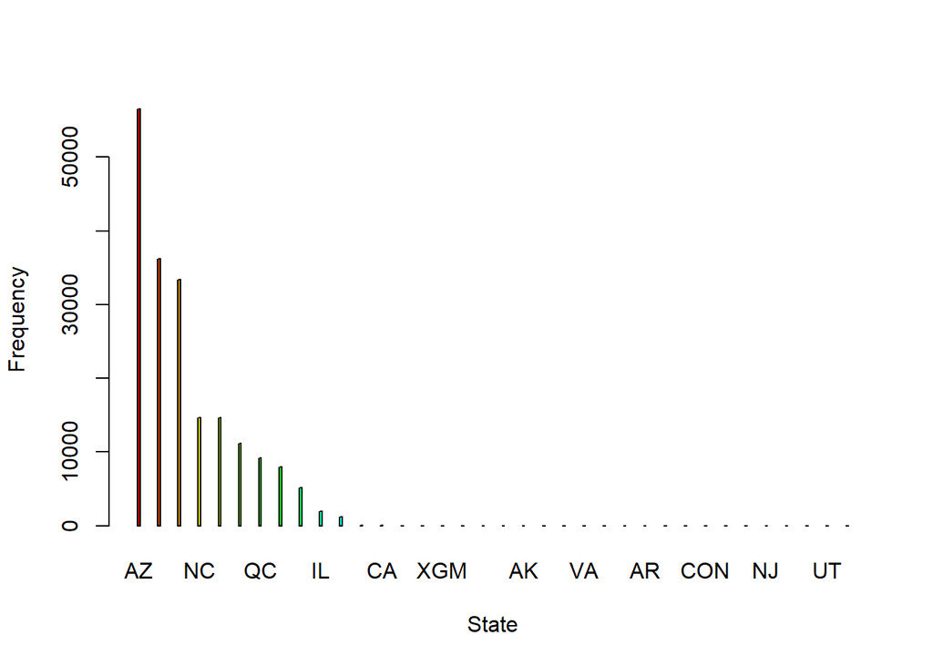

#### *Graph 2:*

In some states like Nebraska & New Mexico there is nearly no data of star ratings. This could imply that, Yelp is not well established in these states or that advertisement strategies are not strong enough in these markets. Such readings may also suggest that there exisits a stronger competitor against Yelp these states.

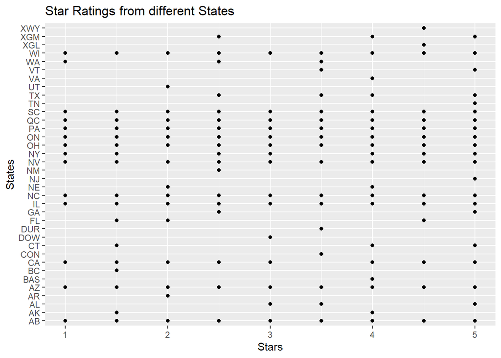

#### *Graph 3:*

There is a varied distribution of ratings across different states which suggests that the location of a business has an impact on it’s rating.

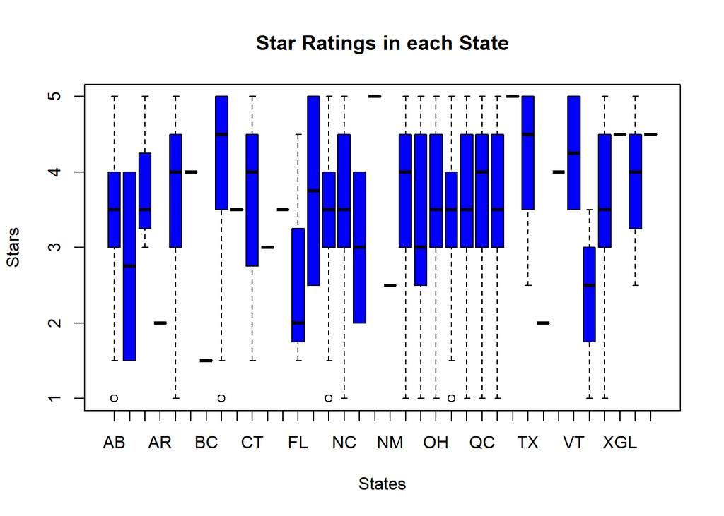

#### *Graph 4:*

It can be concluded that for high number of review counts the average ratings is 4. We can also see that 5 star rating in terms of review counts is fairly low, while most of them ranging between 3.0 & 4.5.

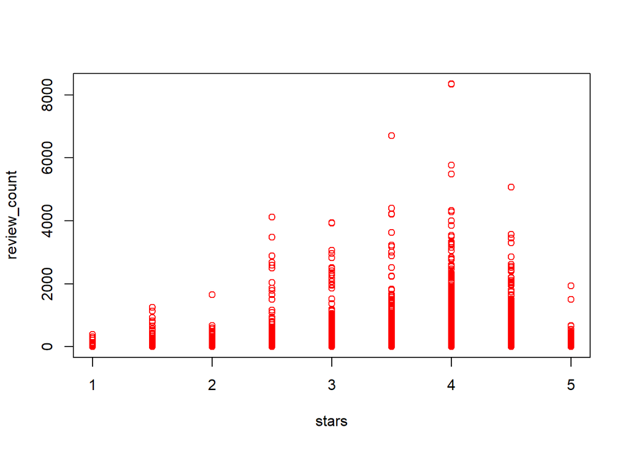

#### *Graph 5:*

By looking at the Box plot between Star Ratings and Active Businesses we can conclude that there is no direct relationship between Star Ratings and the discontinuation of a particular business. This is because, even after achieving higher ratings some businesses have been discontinued. This implies that there may be other factors such as relocation, labor scarcity, increased state taxes, demand of business, automation of services, which may have contributed to the shut down.

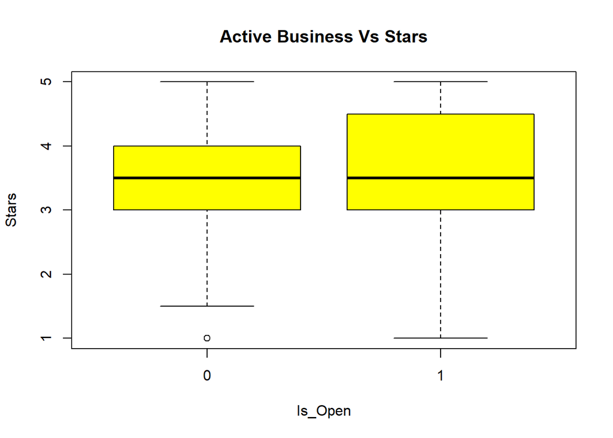

#### *Graph 6:*

Previously, our analysis showed that the highest reviewed Yelp business is that of Restaurants. However, from the boxplot below, we can find which business have received 5 star ratings. These are Pet Services and Gym & Active life.

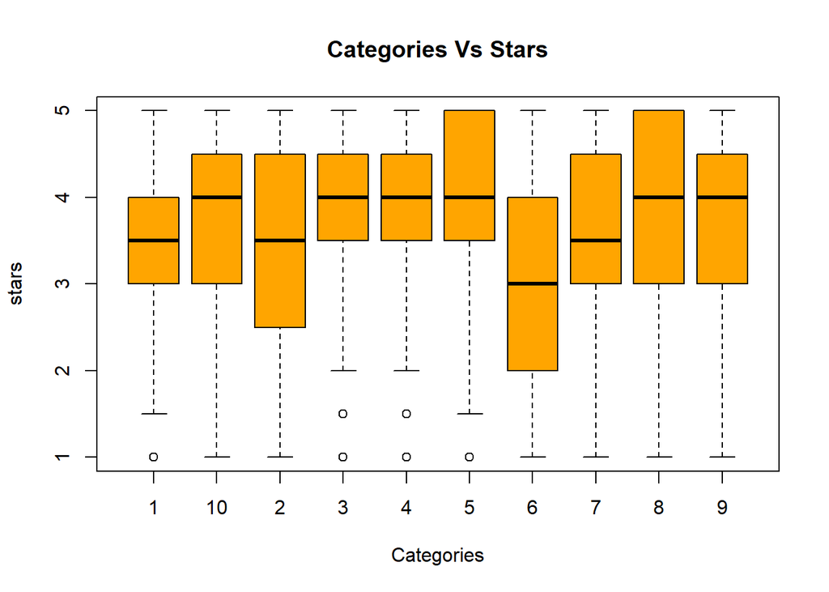

#### *Graph 7:*

1. Mon Ami Gabi
2. Bacchanal Buffet
3. Wicked Spoon
4. Hash House A Go Go
5. Gordon Ramsay BurGR
6. Earl of Sandwich

```
##                       name      city state postal_code latitude longitude
## 82251         Mon Ami Gabi Las Vegas    NV       89109 36.11286 -115.1724
## 89207     Bacchanal Buffet Las Vegas    NV       89109 36.11611 -115.1762
## 35200         Wicked Spoon Las Vegas    NV       89109 36.10955 -115.1762
## 58853   Hash House A Go Go Las Vegas    NV       89109 36.11818 -115.1716
## 141821 Gordon Ramsay BurGR Las Vegas    NV       89109 36.11072 -115.1722
## 83951     Earl of Sandwich Las Vegas    NV       89109 36.10942 -115.1719
##        stars review_count is_open categories
## 82251    4.0         8348       1          1
## 89207    4.0         8339       1          1
## 35200    3.5         6708       1          1
## 58853    4.0         5763       1          1
## 141821   4.0         5484       0          1
## 83951    4.5         5075       1          1
```

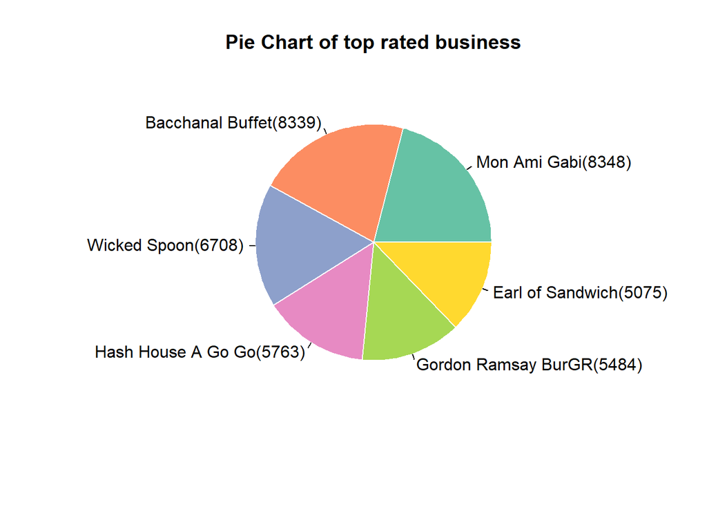

#### *Graph 8:*

Using the library ggmap and the columns latitude and longitude (of the different businesses), we were able to plot the businesses on the map of United States using Google Maps. The density of each individual business in each state and their star ratings can be visualized by this map.

```
## Google's Terms of Service: https://cloud.google.com/maps-platform/terms/.
```

[figure not shown]

```
## [1] "double"
```

## **Chapter 4: Descriptive Statistics**

Using the summary(), we care able to see the various statistical descriptions of the selected columns. For factor variables, we see the values counts of the different levels. For numerical variables, we can see the Minimum, Maximum, 1st and 3rd Quantiles, Mean and Median. For character variables we can see the length of each column and their data types or class.

```
##      name               city              state
##  Length:192127      Length:192127      Length:192127
##  Class :character   Class :character   Class :character
##  Mode  :character   Mode  :character   Mode  :character
##
##
##
##
##  postal_code           latitude       longitude           stars
##  Length:192127      Min.   :33.20   Min.   :-115.49   Min.   :1.000
##  Class :character   1st Qu.:33.64   1st Qu.:-112.27   1st Qu.:3.000
##  Mode  :character   Median :36.14   Median :-111.76   Median :3.500
##                     Mean   :38.54   Mean   : -97.59   Mean   :3.589
##                     3rd Qu.:43.60   3rd Qu.: -79.98   3rd Qu.:4.500
##                     Max.   :51.30   Max.   : -72.91   Max.   :5.000
##
##   review_count     is_open      categories
##  Min.   :   3.00   0: 34063   1      :78622
##  1st Qu.:   4.00   1:158064   7      :25373
##  Median :   9.00              8      :24061
##  Mean   :  33.61              3      :20189
##  3rd Qu.:  25.00              2      :12217
##  Max.   :8348.00              9      :10287
##                               (Other):21378
```

We now check the normality of the dataset with the selected attributes. As we can see, the graph shows that Star Ratings are not normally distributed as anticipated. Moreover, the curve is slightly Left-Skewed.

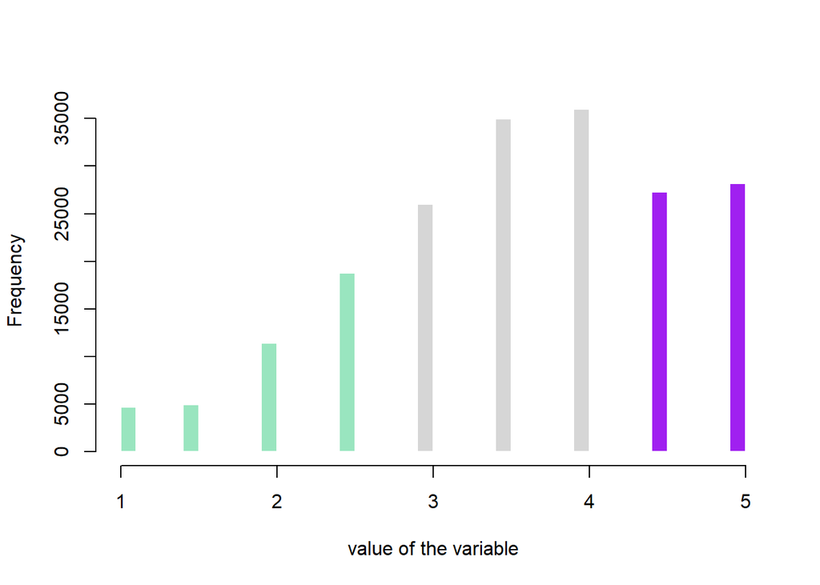

## **Chapter 5: Testing**

In order to perform statistical testing, we have taken a random sample of 15000 rows. The following result shows the first 6 rows of each column of the sample.

```
##                                     name      city state postal_code
## 175964     Southern Hills Baptist Church Las Vegas    NV       89139
## 68102                           Mondiana  Montréal    QC         H2R
## 44033                      Movers Movers  Chandler    AZ       85225
## 184159       Budget Car and Truck Rental   Toronto    ON     M6P 1X2
## 106309                        Kirkland's Charlotte    NC       28273
## 153794 Ali Baba's Middle Eastern Cuisine   Toronto    ON     M5S 1W9
##        latitude  longitude stars review_count is_open categories
## 175964 36.02729 -115.23307   5.0           15       1          4
## 68102  45.53581  -73.61644   4.0            7       0          1
## 44033  33.31941 -111.84212   2.5            3       1          8
## 184159 43.65783  -79.45320   2.5            7       1          6
## 106309 35.09763  -80.98878   3.5            3       1          7
## 153794 43.66673  -79.40459   3.5            3       1          1
```

#### **Analysis:**

The SMART question that asks of the relationship between the ratings and review counts, can be explained here. Since, the reviews are unequally distributed amongst the ratings, we cannot conclude that, as the number of rating increases, for a particular business, it’s rating will improve as well.

```
##
##  One Sample t-test
##
## data:  yfdn_sample$stars
## t = 428.89, df = 14999, p-value < 2.2e-16
## alternative hypothesis: true mean is not equal to 0
## 95 percent confidence interval:
##  3.561946 3.594654
## sample estimates:
## mean of x
##    3.5783
```

#### **Analysis:**

We have 10 different categories of business. For example:- Restaurant/Nightlife… is category 1, etc. We are trying to find whether the different businesses are equally distributed in each city or not, out of the 36 states taken into consideration for our purpose.

```
##
##  Pearson's Chi-squared test with simulated p-value (based on 2000
##  replicates)
##
## data:  yfdn_sample$city and yfdn_sample$categories
## X-squared = 4649.4, df = NA, p-value = 0.06247
```

#### **Test 3: ANOVA Test**

#### *Compares: Review_Count vs. Category*

H0 : Different business categories have equal number of reviews. H1 : Different business categories have different number of reviews. Null hypothesis is rejected.

#### **Analysis:**

Different business categories have unequal number of reviews, which means reviews are not equally distributed across various categories.

```
##  [1] "coefficients"  "residuals"     "effects"       "rank"
##  [5] "fitted.values" "assign"        "qr"            "df.residual"
##  [9] "contrasts"     "xlevels"       "call"          "terms"
## [13] "model"
```

```
##                Df    Sum Sq Mean Sq F value Pr(>F)
## categories      9   6783774  753753   67.22 <2e-16 ***
## Residuals   14990 168091614   11214
## ---
## Signif. codes:  0 '***' 0.001 '**' 0.01 '*' 0.05 '.' 0.1 ' ' 1
```

#### **Test 4: ANOVA Test**

#### *Compares: Stars vs. Category*

H0 : The stars ratings are equally distributed amongst different business categories. H1 : The stars ratings are not equally distributed amongst different business categories. Null hypothesis is rejected.

#### **Analysis:**

Different business categories have unequal star ratings, which means ratings are not equally distributed across various categories.

```
##  [1] "coefficients"  "residuals"     "effects"       "rank"
##  [5] "fitted.values" "assign"        "qr"            "df.residual"
##  [9] "contrasts"     "xlevels"       "call"          "terms"
## [13] "model"
```

```
##                Df Sum Sq Mean Sq F value Pr(>F)
## categories      9    581   64.52   64.13 <2e-16 ***
## Residuals   14990  15080    1.01
## ---
## Signif. codes:  0 '***' 0.001 '**' 0.01 '*' 0.05 '.' 0.1 ' ' 1
```

## **Chapter 6: Limitations**

Despite finding an answer to our SMART Questions, we came across certain limitations during our analysis, in terms of our data. These were: 1. Our data was extremely unclean which resulted in very time-consuming data cleaning. This propelled us to eliminate several rows and columns with NA values. 2. Due to elimination, we were able to work with only 36 states out of the total 50 states. Hence, in order to perform a country-wide search we would require a much cleaner dataset. 3. Our SMART questions did not include a Time-series question. This is because the dataset chosen for EDA did not consist of a time-specific attribute.

## **Chapter 7: Future Work**

The Yelp dataset consists of sub-domains such as Business, Checkin, Reviw, Tip and User. Each of these sub-datasets consist of a large number of datapoints. For initial EDA and Phase 1 of the project, we chose the Business Dataset. However, given the scope of answering several other questions in Phase 2, we aim to make use of multiple attributes from most of the sub-datasets and combining them to create a single dataset, which allows us to answer our questions and maybe even find something new!